# GR5243 Project 1 (Yihan Zhang)

### Topic of Project

#### Impact of shopping on happiness among different parenthood categories.

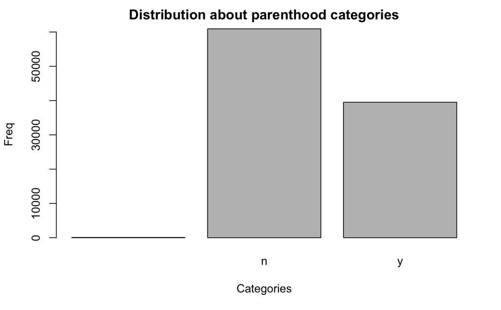

Before diving into the data, first we can observe the distribution of data that we are interested in. From the above bar plot, we can observe that there are more people do not have any child (represented by the column n). The number of people in this group is about 60,000. By contrast, the number of people who do have one or more children are approximately 40,000.

In addition, there exist a part of people who did not indicated their parenthood status when collecting the data.

```r
data_df <- data.frame(sentences = df$cleaned_hm)

# Convert the dataframe to a single character vector
text <- tolower(paste(data_df$sentences, collapse = " "))

# Tokenize the text into words
words <- unlist(strsplit(text, split = "\\W+"))

# Count the frequency
word_freq <- table(words)

# Display
print(sort(word_freq, decreasing = TRUE))
```

[output not shown]

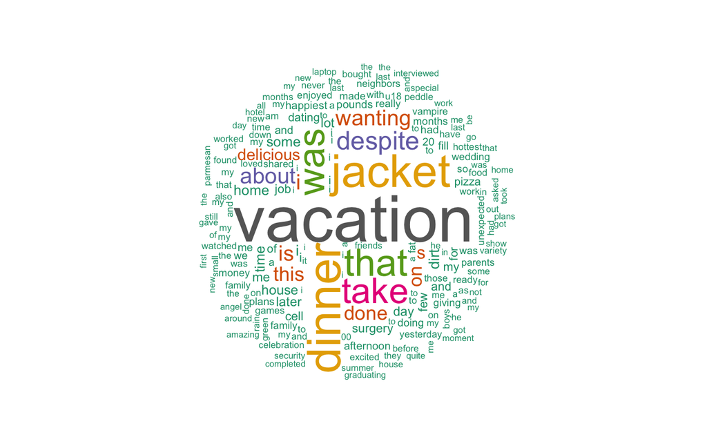

```r
library(wordcloud)
# Using the word_freq data
wordcloud(words = words, freq = word_freq, min.freq = 1,
          max.words=200, random.order=FALSE, colors=brewer.pal(8, "Dark2"))
```

### Analysis Processes (Parenthood)

We can use word2vec model in the Nature Language Processing to analyze the contents of different text based on their potential theme. To use word2vec model, according to Claire’s tutorial, we need to lemmatize the cleaned_hm text with regard to speech tag of each word (verb, adverb, noun, adjective). The detailed process can be refer to the process_data function in tutorial by Claire He.

Based on the column of parenthood, we can divide the clean_hm data set to two groups, and build models for each data set.

After constructing the model based on new data set. We want to find words that most likely related to shopping, and them use them to compare with the most similar words with happiness for the two groups of people.

Furthermore, we can plot the words using the coordinate given by the models, and hence we can visulize the relationship between words of “shopping” and “happiness”.

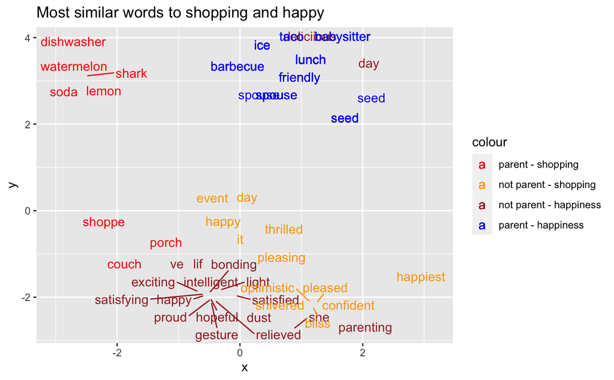